# Extra results

Alberto Acerbi

We need to load the usual functions in main.R.

```r
source("main.R")
```

### Correlation between population size and cultural complexity

We can use the data already produced to calculate the correlation between population size and number of traits (habitual + customary + present). Notice that because we know the capacities of the oranzees do not change, we do not need to hypothesise an effect of “cultural intelligence” (an onthogentic rising of innovating capabilities due to previous cultural effects) to explain the correlation, but simply that, with bigger populations, there are more innovations.

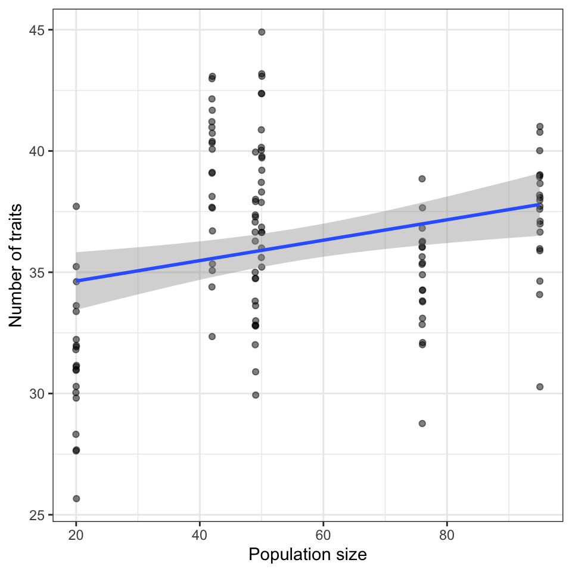

```r
data <- read_csv("sims_for_ms/data/figure_2.csv")
pop_sizes <- c(20, 76, 50, 95, 42, 49)
list_pop <- c("Uossob", "Iat Forest", "Ebmog", "Elaham", "Elabik", "Ognodub")

customary <- c()
habitual <- c()
present <- c()

for( r in 1:20){
  for(pop in list_pop){
    customary <- c(customary, dim(data[data$run==r & data$population==pop & data$code=="customary",])[1])
    habitual <- c(habitual, dim(data[data$run==r & data$population==pop & data$code=="habitual",])[1])
    present <- c(present, dim(data[data$run==r & data$population==pop & data$code=="present",])[1])
  }
}
figure_2_extra <- tibble(behaviours = customary + present + habitual,
              pop_size = rep(pop_sizes, 20))
ggplot(data = figure_2_extra, aes(x=pop_size, y=behaviours)) +
  geom_jitter(width = 0.05, alpha = 0.5) +
  theme_bw() +
  stat_smooth(method = lm)  +
  labs(x="Population size", y="Number of traits")
```

We found a correlation but we need to check that it holds for “cultural” traits:

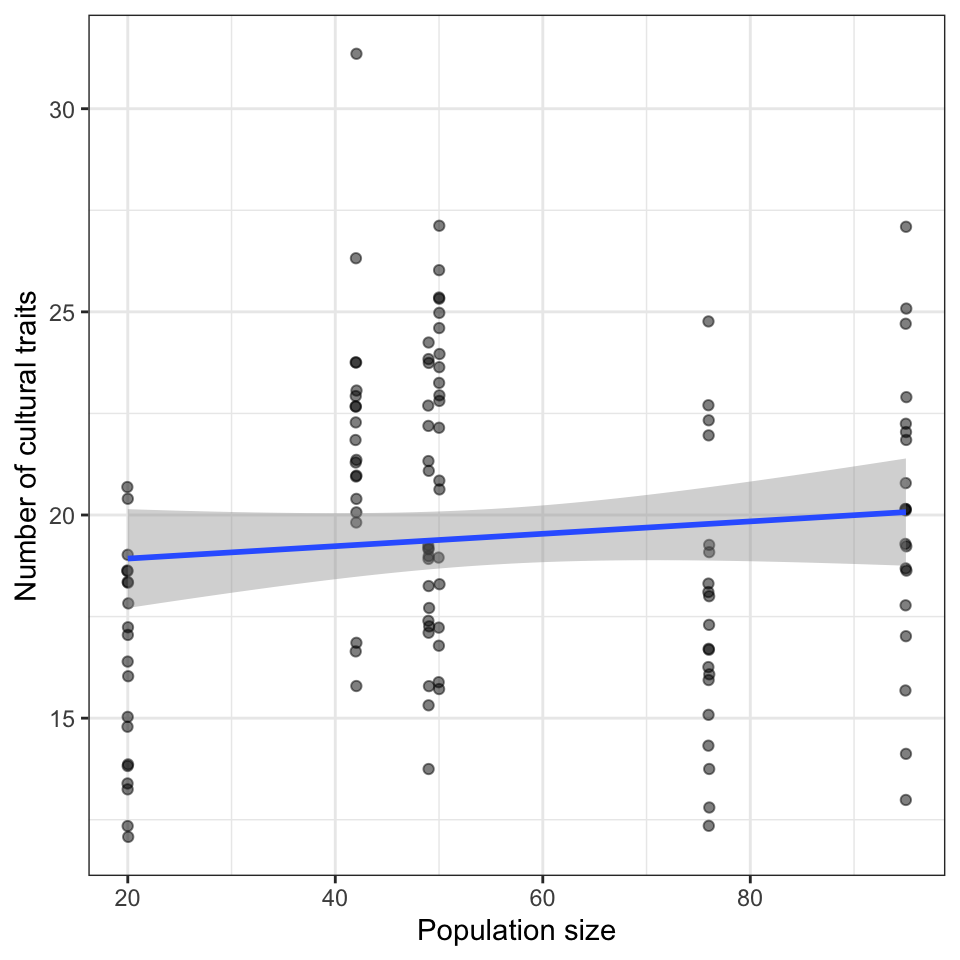

```r
process <- data %>%
  group_by(behaviour, run) %>%
  summarise(A = !("absent" %in% code) && !("ecological explanation" %in% code),
            B = !("habitual" %in% code) && !("customary" %in% code),
            C = !("absent" %in% code) && ("ecological explanation" %in% code)) %>%
  ungroup() %>%
  mutate (D = !(A | B | C)) %>%
  group_by(run)

pop_sizes <- c(20, 76, 50, 95, 42, 49)
list_pop <- c("Uossob", "Iat Forest", "Ebmog", "Elaham", "Elabik", "Ognodub")

customary <- c()
habitual <- c()
present <- c()

for(r in 1:20){
  cultural_behaviours <- process[process$run==r & process$D=="TRUE",]$behaviour
  for(pop in list_pop){
    customary <- c(customary, sum(data[data$run==r & data$population==pop & data$code=="customary",]$behaviour %in% cultural_behaviours))
    habitual <- c(habitual, sum(data[data$run==r & data$population==pop & data$code=="habitual",]$behaviour %in% cultural_behaviours))
    present <- c(present, sum(data[data$run==r & data$population==pop & data$code=="present",]$behaviour %in% cultural_behaviours))
  }
}
figure_2_extra_b <- tibble(behaviours = customary + present + habitual,
              pop_size = rep(pop_sizes, 20))
ggplot(data = figure_2_extra_b, aes(x=pop_size, y=behaviours)) +
  geom_jitter(width = 0.05, alpha = 0.5) +
  theme_bw() +
  stat_smooth(method = lm)  +
  labs(x="Population size", y="Number of cultural traits")
```

As the data are unclear, it is worth to run more simulations to understand better the relationship between population size and complexity. Let’s explore the same condition, but for 100 runs (as usual, the simulatons are run only once, and the data loaded here).

```r
tic()
test <- run_oranzees(t_max = 6000, alpha_e = 0.8, alpha_g = 0.2, S = 1, init_world = TRUE, n_run = 100)
toc()
write_csv(test, "extra_results/data/pop_complexity.csv")
```

Let’s plot, with the same code used before, the correlation for all behaviours:

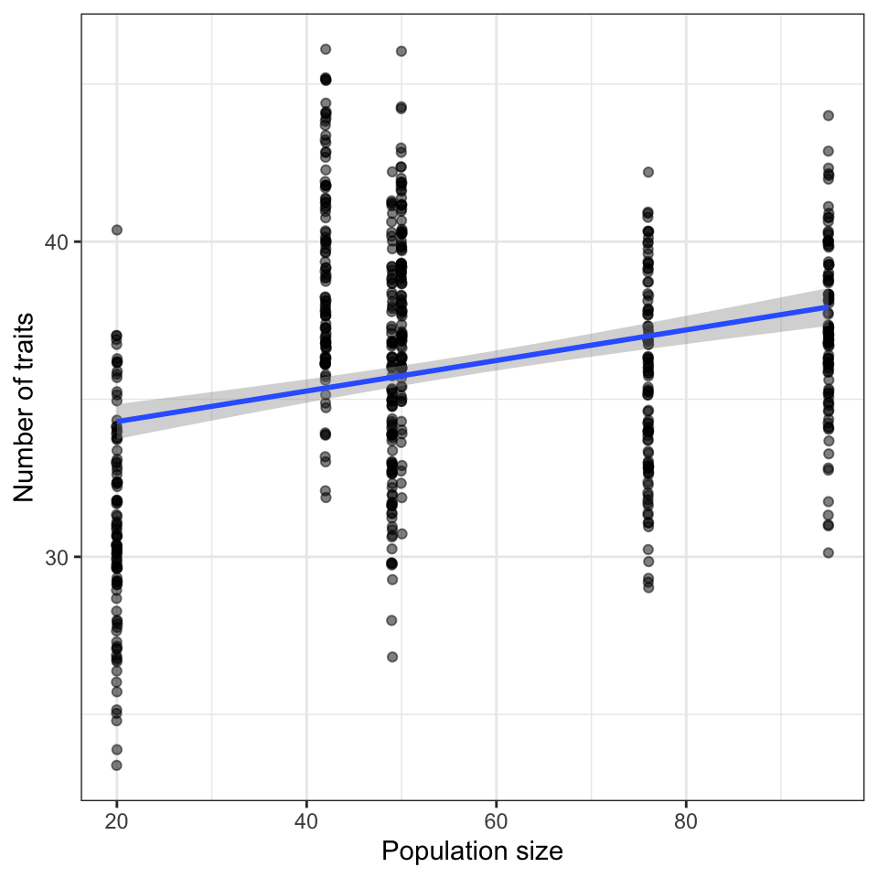

And, now, for cultural behaviours:

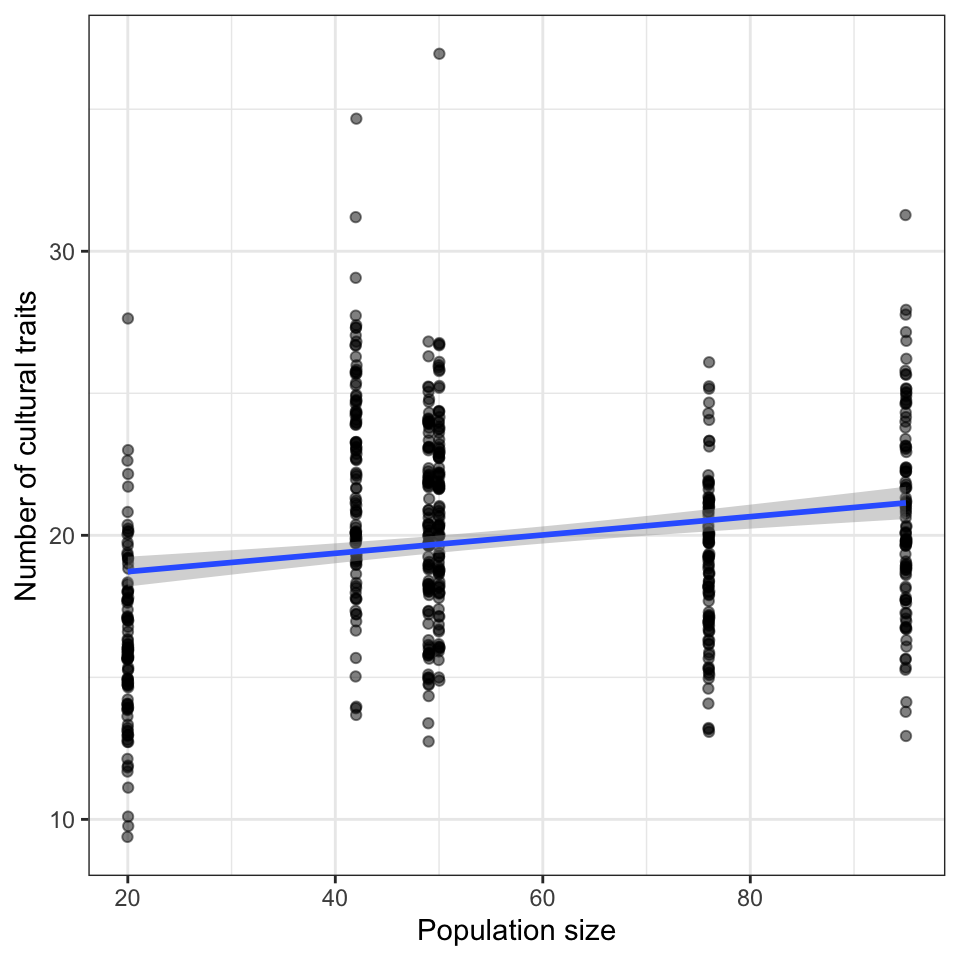

We can quickly check the actual correlation value:

```r
library(Hmisc)
rcorr(out$pop_size, out$behaviours, type="spearman")
```

```
##     x   y
## x 1.0 0.2
## y 0.2 1.0
##
## n= 600
##
##
## P
##   x  y
## x     0
## y  0
```

There is a weak ($r=0.2$), but significant ($p=0.0000003271925$) positive correlation.